# Repurp: Drug–Gene Interaction Network Visualisation

# Part 6: Tile heatmap — Drug × Gene matrix

`plot_dgi_heatmap()` renders a ggplot2 tile matrix where rows are drugs sorted by drug class then degree, columns are genes sorted by degree, and fill encodes the dominant interaction type for each drug–gene pair.

This plot is ideal for publications where a compact, annotation-rich overview of the entire drug × gene space is needed.

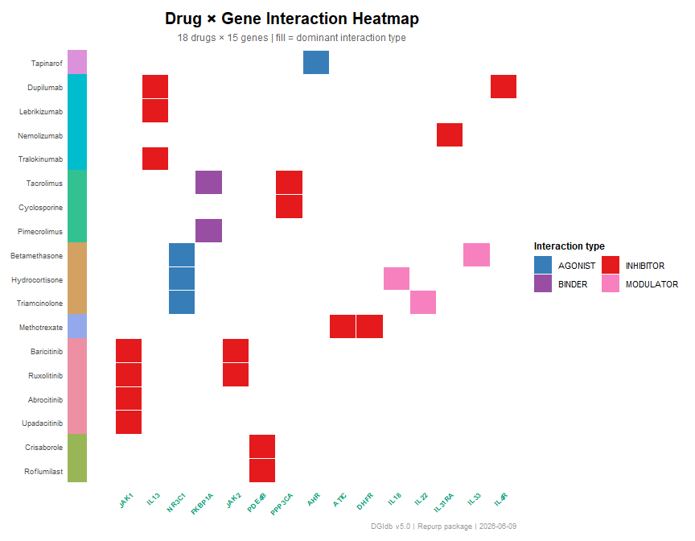

```r
p_heat <- plot_dgi_heatmap(
  dgi_edges  = dgi_e,
  drug_info  = repurp_ad_drugs(),
  title      = "Drug × Gene Interaction Heatmap",
  max_drugs  = 20L,
  max_genes  = 15L
)
```

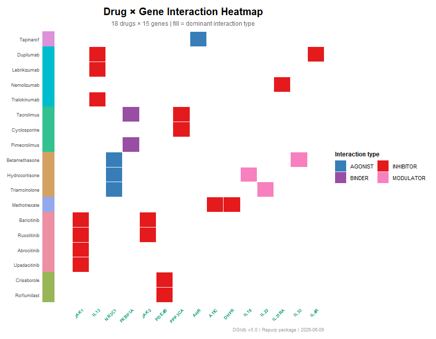

```r
p_heat
```

Key parameters:

| Parameter | Default | Effect |
| --- | --- | --- |
| `max_drugs` | `60L` | Top-N drugs by degree to display |
| `max_genes` | `50L` | Top-N genes by degree to display |
| `drug_info` | `NULL` | Data frame with `drug_name` + `category` for row strips |
| `edge_palette` | `dgi_edge_colors` | Named hex vector for interaction types |

**Reading the heatmap:** Each cell represents a drug–gene pair with at least one recorded interaction. The fill colour shows the most frequent interaction type between that drug and gene. White cells indicate absence of interaction. Rows are grouped by drug class, making it easy to spot within-class gene targeting patterns.

# Part 7: Sankey / alluvial flow diagram

`plot_dgi_sankey()` renders a three-axis alluvial plot (requires `ggalluvial`):

$$\text{Drug Class} \;\longrightarrow\; \text{Drug} \;\longrightarrow\;
\text{Gene}$$

Band width is proportional to the number of connections. Colour can encode either drug class (`fill_by = "drug_class"`) or interaction type (`fill_by = "edge_type"`).

## 6a — Colour by drug class

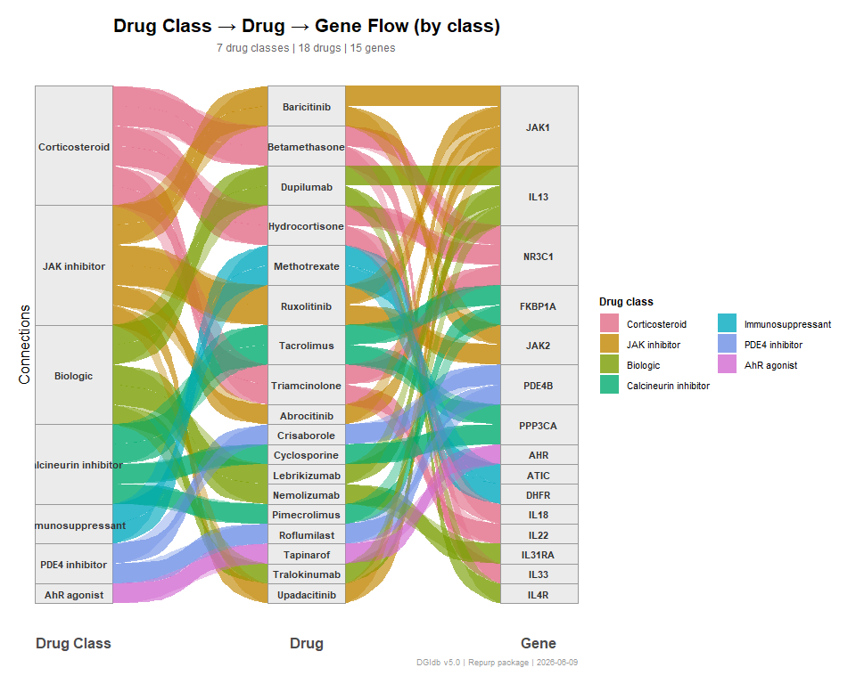

```r
p_sank_cls <- plot_dgi_sankey(
  dgi_edges  = dgi_e,
  drug_info  = repurp_ad_drugs(),
  fill_by    = "drug_class",
  title      = "Drug Class → Drug → Gene Flow (by class)",
  max_genes  = 15L
)
```

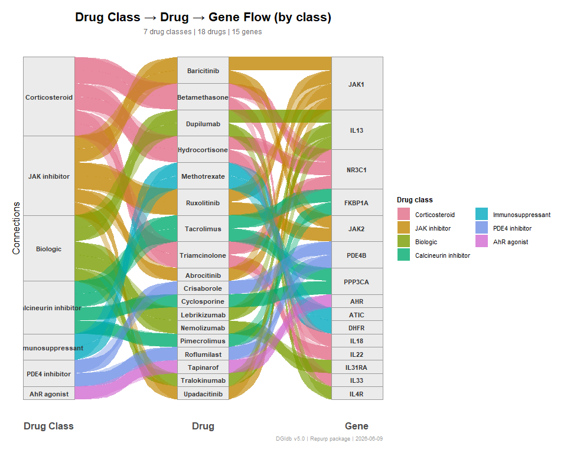

```r
p_sank_cls
```

## 6b — Colour by interaction type

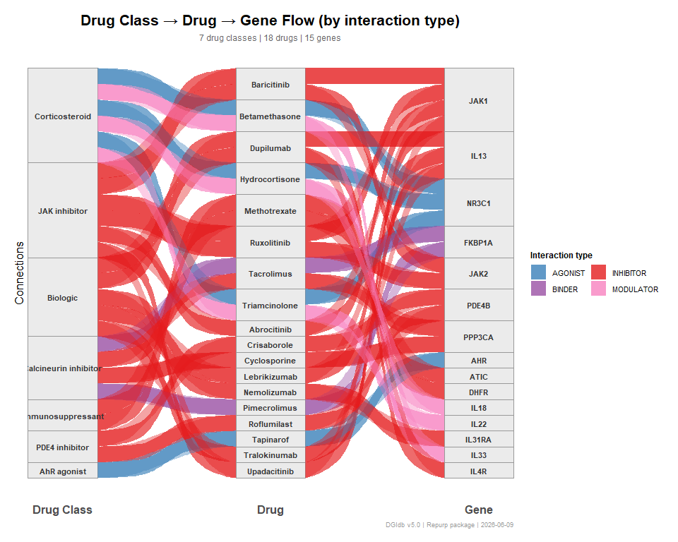

```r
p_sank_typ <- plot_dgi_sankey(
  dgi_edges  = dgi_e,
  drug_info  = repurp_ad_drugs(),
  fill_by    = "edge_type",
  title      = "Drug Class → Drug → Gene Flow (by interaction type)",
  max_genes  = 15L
)
```

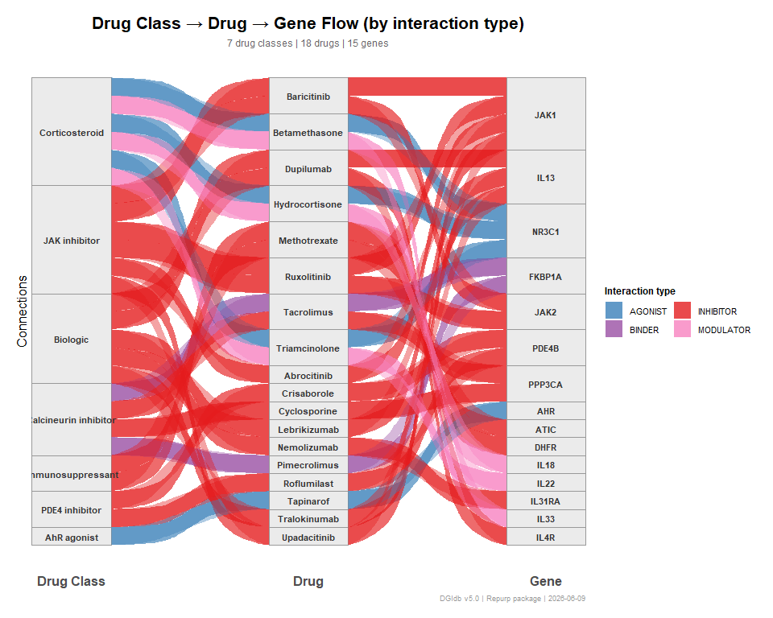

```r
p_sank_typ
```

Key parameters:

| Parameter | Default | Effect |
| --- | --- | --- |
| `fill_by` | `"drug_class"` | Alluvia fill: `"drug_class"` or `"edge_type"` |
| `min_connections` | `1L` | Minimum edges per drug–gene pair to draw |
| `max_genes` | `30L` | Top-N genes to include |

**Reading the Sankey:** Follow a band from left to right to trace a drug class’s exposure through individual drugs into specific biomarker genes. Bands that widen or narrow indicate unequal distribution of drug–gene connections within a class. The `fill_by = "edge_type"` view reveals whether a drug class predominantly inhibits, activates, or binds its targets.

# Part 8: Dot matrix — Gene × Drug-Class bubble chart

`plot_dgi_dotmatrix()` produces a bubble/balloon plot where:

- **Y axis** = genes (sorted by total connections, most-connected at top)
- **X axis** = drug classes (sorted by total connections)
- **Dot size** = number of drug–gene connections within that class
- **Dot colour** = dominant interaction type
- **Label inside dot** = exact connection count

This is arguably the most information-dense single-panel summary for a drug repurposing manuscript.

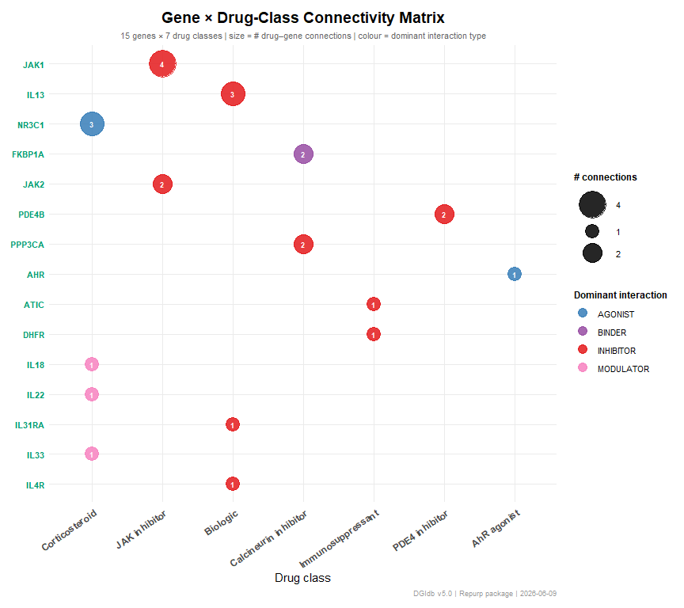

```r
p_dot <- plot_dgi_dotmatrix(
  dgi_edges  = dgi_e,
  drug_info  = repurp_ad_drugs(),
  title      = "Gene × Drug-Class Connectivity Matrix",
  max_genes  = 15L
)
```

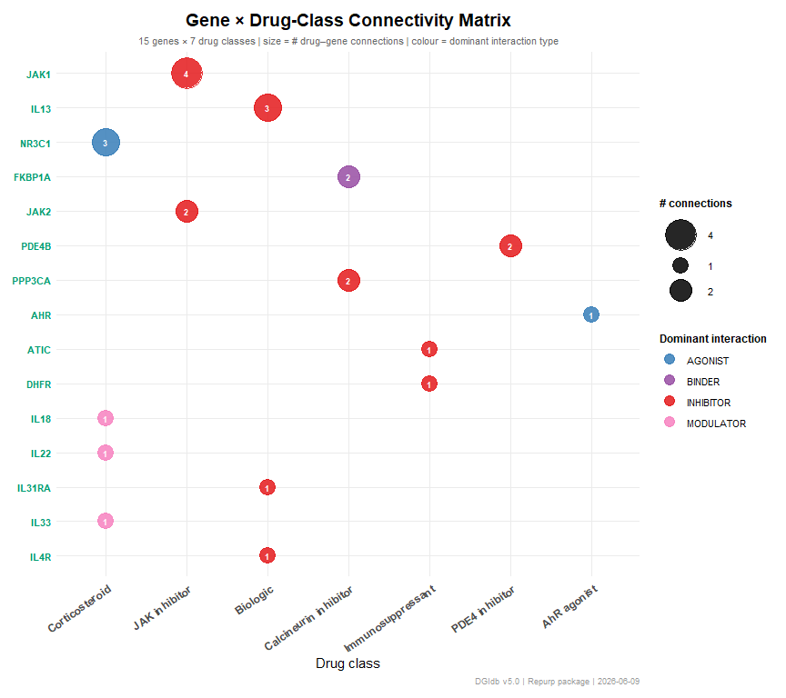

```r
p_dot
```

Key parameters:

| Parameter | Default | Effect |
| --- | --- | --- |
| `max_genes` | `40L` | Top-N genes by total degree |
| `min_connections` | `1L` | Minimum connections to draw a dot |
| `edge_palette` | `dgi_edge_colors` | Interaction-type colour mapping |

# Part 9: Multi-panel figures with patchwork

All ggraph/ggplot2 plot functions return a `ggplot` object, so they compose directly with `patchwork`:

```r
library(patchwork)

# Build individual panels
p_enh <- plot_dgi_ggraph_enhanced(dgi_e, mode = "core", seed = 42L)
p_dot <- plot_dgi_dotmatrix(dgi_e, drug_info = repurp_ad_drugs())
p_ht  <- plot_dgi_heatmap(dgi_e, drug_info = repurp_ad_drugs())

# Two-column layout with shared title
(p_enh | p_dot) /
  p_ht +
  patchwork::plot_annotation(
    title    = "AD Drug–Biomarker Network Summary",
    subtitle = "Left: FR network (core). Right: dot matrix. Bottom: heatmap.",
    theme    = ggplot2::theme(plot.title = ggplot2::element_text(size = 16, face = "bold"))
  )
```

For igraph / circlize base-R plots in multi-panel layouts, use `grDevices::recordPlot()` / `replayPlot()` or the `cowplot::draw_grob()` approach:

```r
library(cowplot)
p_ig <- cowplot::as_grob(~plot_dgi_igraph(synth_dgi))
cowplot::plot_grid(p_ig, p_enh, ncol = 2, labels = c("A", "B"))
```

# Part 10: Comparing multiple gene sets

A common AD repurposing workflow runs the DGI pipeline separately for two differential-expression contrasts and overlays the results:

```r
# Set 1: systemic AD vs healthy controls
dgi_sys  <- prepare_dgi_data("dgi_systemic.tsv",   gene_list = de_sys_genes)

# Set 2: non-systemic AD vs healthy controls
dgi_nsys <- prepare_dgi_data("dgi_nonsystemic.tsv", gene_list = de_nsys_genes)

# Convert both
e_sys  <- dplyr::transmute(dgi_sys,  from = Gene, to = Drug, edge_type = InteractionType)
e_nsys <- dplyr::transmute(dgi_nsys, from = Gene, to = Drug, edge_type = InteractionType)

# ggraph panels — returns ggplot, so patchwork works directly
p1 <- plot_dgi_ggraph_enhanced(e_sys,  mode = "core", title = "Systemic AD")
p2 <- plot_dgi_ggraph_enhanced(e_nsys, mode = "core", title = "Non-systemic AD")
p1 + p2

# Dot-matrix side-by-side
d1 <- plot_dgi_dotmatrix(e_sys,  drug_info = repurp_ad_drugs(), title = "Systemic AD")
d2 <- plot_dgi_dotmatrix(e_nsys, drug_info = repurp_ad_drugs(), title = "Non-systemic AD")
d1 + d2
```

Genes present in both sets can be highlighted by adding a shared-gene column to the node aesthetics before plotting.

# Colour reference

## Interaction types (`dgi_edge_colors`)

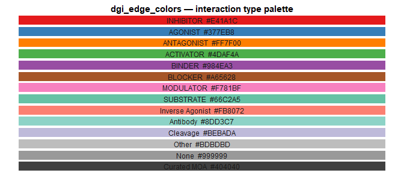

```r
ec <- data.frame(
  type  = names(dgi_edge_colors),
  hex   = unname(dgi_edge_colors),
  stringsAsFactors = FALSE
)
ec$type <- factor(ec$type, levels = rev(ec$type))

ggplot2::ggplot(ec, ggplot2::aes(x = 1, y = type, fill = hex)) +
  ggplot2::geom_tile(color = "white", width = 0.9, height = 0.85) +
  ggplot2::geom_text(ggplot2::aes(label = paste0(type, "  ", hex)),
                     x = 1, size = 3.2, hjust = 0.5, color = "grey10") +
  ggplot2::scale_fill_identity() +
  ggplot2::theme_void() +
  ggplot2::labs(title = "dgi_edge_colors — interaction type palette") +
  ggplot2::theme(
    plot.title = ggplot2::element_text(size = 11, face = "bold", hjust = 0.5)
  )
```

## Drug classes (`repurp_class_colors()`)

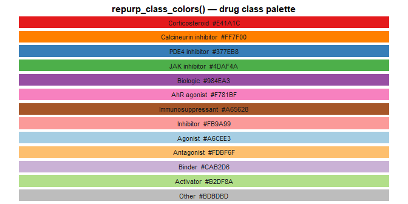

```r
rc <- data.frame(
  class = names(repurp_class_colors()),
  hex   = unname(repurp_class_colors()),
  stringsAsFactors = FALSE
)
rc$class <- factor(rc$class, levels = rev(rc$class))

ggplot2::ggplot(rc, ggplot2::aes(x = 1, y = class, fill = hex)) +
  ggplot2::geom_tile(color = "white", width = 0.9, height = 0.85) +
  ggplot2::geom_text(ggplot2::aes(label = paste0(class, "  ", hex)),
                     x = 1, size = 3.0, hjust = 0.5, color = "grey10") +
  ggplot2::scale_fill_identity() +
  ggplot2::theme_void() +
  ggplot2::labs(title = "repurp_class_colors() — drug class palette") +
  ggplot2::theme(
    plot.title = ggplot2::element_text(size = 11, face = "bold", hjust = 0.5)
  )
```

## Node types (`dgi_node_colors`)

```r
data.frame(
  node_type = names(dgi_node_colors),
  hex       = unname(dgi_node_colors)
)
```

```
#>   node_type     hex
#> 1      Gene #009E73
#> 2      Drug #F0E442
#> 3   Pathway #6A3D9A
```

# Summary

All Repurp exported functions — v0.2.0.

| Function | Engine | Output | New in v0.2 |
| --- | --- | --- | --- |
| prepare_dgi_data() | dplyr / stringr | tibble |  |
| standardize_dgi_edges() | base R / dplyr | tibble | Yes |
| score_drug_repurposing() | dplyr | ranked tibble | Yes |
| summarize_biomarker_coverage() | dplyr | summary tibble | Yes |
| summarize_drug_classes() | dplyr | summary tibble | Yes |
| score_expression_reversal() | dplyr | ranked tibble | Yes |
| plot_dgi_igraph() | igraph + qgraph | SVG + PNG |  |
| plot_dgi_igraph_core() | igraph + qgraph | SVG + PNG |  |
| plot_dgi_tripartite_igraph() | igraph + qgraph | SVG + PNG |  |
| plot_dgi_ggraph() | ggraph + tidygraph | ggplot |  |
| plot_dgi_ggraph_core() | ggraph + tidygraph | ggplot |  |
| plot_dgi_ggraph_enhanced() | ggraph + ggrepel + ggnewscale | ggplot |  |
| plot_dgi_ad_network() | ggplot2 + ggrepel + ggnewscale | ggplot |  |
| build_visnetwork() | visNetwork | htmlwidget |  |
| build_visnetwork_tripartite() | visNetwork | htmlwidget |  |
| save_visnetwork() | visNetwork | HTML file path |  |
| plot_chord_dgi() | circlize | SVG |  |
| plot_chord_dgi_combined() | circlize | SVG |  |
| plot_dgi_heatmap() | ggplot2 | ggplot | Yes |
| plot_dgi_sankey() | ggplot2 + ggalluvial | ggplot | Yes |
| plot_dgi_dotmatrix() | ggplot2 | ggplot | Yes |